# R Notebook

```r
library(officer)
library(rvg)
library(tidyverse)
```

W pakiecie officer mamy `read_pptx`

- `read_pptx()` – to tworzymy nowy szablon prezentacji
- `read_pptx(path = "ścieżka")` – wczytujemy plik power point z dysku

```r
prez <- read_pptx()
prez
```

```
pptx document with 0 slide(s)
Available layouts and their associated master(s) are:
```

| layout | master |
| --- | --- |
| Title Slide | Office Theme |
| Title and Content | Office Theme |
| Section Header | Office Theme |
| Two Content | Office Theme |
| Comparison | Office Theme |
| Title Only | Office Theme |
| Blank | Office Theme |

Funkcja `layout_summary` podsumowuje typy slajdów, które są możliwe do wstawienia

```r
layout_summary(prez)
```

| layout | master |
| --- | --- |
| Title Slide | Office Theme |
| Title and Content | Office Theme |
| Section Header | Office Theme |
| Two Content | Office Theme |
| Comparison | Office Theme |
| Title Only | Office Theme |
| Blank | Office Theme |

Jak należy pracować z pakietem officer

- tworzymy plik z funkcją `read_pptx()` %>%
  - dodajemy slajd z funkcją `add_slide()` %>%
    - uzupełniamy slajd z funkcjami zaczynającymi się od `ph_*` %>%
    - uzupełniamy slajd z funkcjami zaczynającymi się od `ph_*` %>%
    - uzupełniamy slajd z funkcjami zaczynającymi się od `ph_*` %>%
  - dodajemy slajd z funkcją `add_slide()` %>%
    - uzupełniamy slajd z funkcjami zaczynającymi się od `ph_*` %>%
    - uzupełniamy slajd z funkcjami zaczynającymi się od `ph_*` %>%
    - uzupełniamy slajd z funkcjami zaczynającymi się od `ph_*` %>%
  - dodajemy slajd z funkcją `add_slide()` %>%
    - uzupełniamy slajd z funkcjami zaczynającymi się od `ph_*` %>%
    - uzupełniamy slajd z funkcjami zaczynającymi się od `ph_*` %>%
    - uzupełniamy slajd z funkcjami zaczynającymi się od `ph_*` %>%
  - zapisujemy z funkcją `print()`

Zakładamy, że nasza prezentacja będzie składała się z następujących slajdów:

- slajd tytułowy – załatwione
- slajd z tytułem i treścią
- slajd z wykresem z ggplot2
- slajd z tabelą
- slajd na pożegnanie

```r
prez <- prez %>%
  add_slide(layout = "Title Slide", master = "Office Theme") %>%
    ph_with(value = "Prezentacja z NAD2",
            location = ph_location_type(type = "ctrTitle"))

print(prez, target = '../results/prezentacja-nad2.pptx')
```

Dodajmy slajd z tytułem oraz treścią w postaci listy punktowanej

```r
prez <- prez %>%
  add_slide(layout = "Title and Content", master = "Office Theme") %>%
  ph_with(value = "Plan prezentacji",
          location = ph_location_type(type = "title")) %>%
  ph_with(value = c("Wstęp", "Analiza", "Podsumowanie"),
          location = ph_location_type(type = "body"))

print(prez, target = '../results/prezentacja-nad2.pptx')
```

Chcemy dodać slajd z wykresem z pakietu ggplot2 ale chcielibyśmy aby ten wykres był edytowalny.

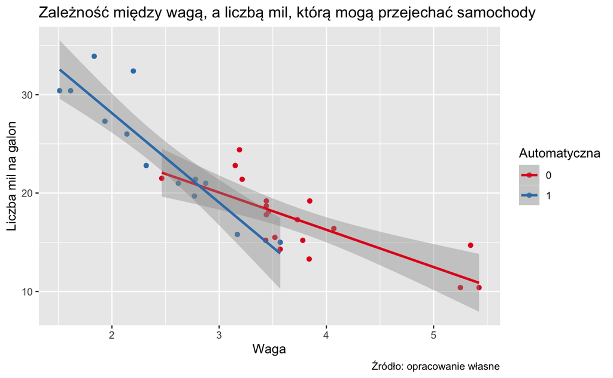

```r
wykres <- ggplot(data = mtcars, aes(x = wt, y = mpg, color = factor(am))) +
  geom_point() +
  geom_smooth(method = "lm") +
  scale_color_brewer(type = "qual", palette = "Set1") +
  labs(x = "Waga", y = "Liczba mil na galon",
       title = "Zależność między wagą, a liczbą mil, którą mogą przejechać samochody",
       caption = "Źródło: opracowanie własne",
       color = "Automatyczna")

wykres
```

Dodajemy slajd z wykresem, którego nie możemy edytować

```r
prez <- prez %>%
  add_slide(layout = "Title and Content", master = "Office Theme") %>%
  ph_with(value = "Wykres zależnosci między wagą, a liczbą mil/galon",
          location = ph_location_type(type = "title")) %>%
  ph_with(value = wykres,
          location = ph_location_type(type = "body"))
```

Dodanie tego samego wykresu ale edytowalnego (jako grafika wektorowa)

```r
wykres_edytowalny <- dml(ggobj = wykres)


prez <- prez %>%
  add_slide(layout = "Title and Content", master = "Office Theme") %>%
  ph_with(value = "Wykres (edytowalny)",  ## tu wprowadziłem nowy tytuł
          location = ph_location_type(type = "title")) %>%
  ph_with(value = wykres_edytowalny, ## tytaj wprowadziłem nowy obiekt (wykres => wykres_edytowalny)
          location = ph_location_type(type = "body"))
print(prez, target = "../results/prezentacja-nad2.pptx")
```